# Problem Set: Sampling Distributions (Answer Key)

Joe Ornstein

November 17, 2021

First, load the dataset.

```r
library(tidyverse)
library(here)

load(here('data/ces-2020/cleaned-CES.RData'))
```

Next, we’ll compute the percent of respondents that support tariffs, and the difference between men and women.

```r
# create female and pro_tariffs variables
ces <- mutate(ces,
              female = as.numeric(gender == 'Female'),
              pro_tariffs = as.numeric(china_tariffs == 'Support'))

# percent that support tariffs is the mean of the 0-1 variable
ces$pro_tariffs %>% na.omit %>% mean
```

```
## [1] 0.5923444
```

```r
# difference in means by gender
lm(pro_tariffs ~ female, data = ces)
```

```
##
## Call:
## lm(formula = pro_tariffs ~ female, data = ces)
##
## Coefficients:
## (Intercept)       female
##    0.594078    -0.003013
```

In the broader population[^1], there is almost no difference between men and women on support for tariffs. But suppose we only had a sample of 100. How weird could a sample of 100 get? Let’s create the `get_estimate()` function to find out.

```r
get_estimate <- function(sample_size = 100){

  # draw a sample
  sample_data <- slice_sample(ces, n = sample_size)

  # compute the difference in means
  lm_sample <- lm(pro_tariffs ~ female, data = sample_data)

  # return the coefficient
  coef(lm_sample)['female']
}

get_estimate()
```

```
##    female
## 0.0952381
```

```r
get_estimate()
```

```
##     female
## 0.06547619
```

Next, let’s use that function to generate a sampling distribution with 25,000 draws.

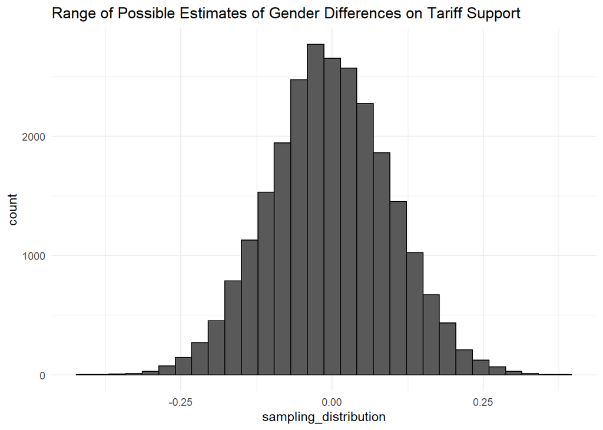

```r
sampling_distribution <- replicate( 25000, get_estimate() )

ggplot(mapping = aes(x=sampling_distribution)) +
  geom_histogram(color = 'black') +
  theme_minimal() +
  labs(title = 'Range of Possible Estimates of Gender Differences on Tariff Support')
```

```r
sd(sampling_distribution)
```

```
## [1] 0.09958075
```

```r
min(sampling_distribution)
```

```
## [1] -0.4177578
```

```r
max(sampling_distribution)
```

```
## [1] 0.374359
```

Despite the fact that the true value is practically zero, there is a wide range of statistics you might compute in a sample of 100. Here is the probability that you’d get an estimate a gender difference greater than 10%:

```r
sum(abs(sampling_distribution) > 0.1) / length(sampling_distribution) * 100
```

```
## [1] 31.62
```

This, by the way, is the foundation of null hypothesis testing. What’s the range of estimates you would expect to get if the true value of your statistic was actually zero?

[^1]: The broader population of CES respondents, that is! We’re continuing here with the useful fiction that this is the population we care about…